# Bank EDA and CHURN prediction

# Introduction

This report presents an analysis of bank customer churn data, obtained from the Customer-Churn-Record dataset available on Kaggle (source: https://www.kaggle.com/datasets/radheshyamkollipara/bank-customer-churn?resource=download). The dataset contains information about 10,000 bank customers including their demographic characteristics, account details, transaction history and churn status. The primary objectives of this analysis are Exploratory Data Analysis (EDA) and Churn Prediction.

The use of EDA will help in understanding the structure and distribution of the data, identify patterns and the reasons why customers churn. Through the use of Random Forest we can estimate the probability of churn for retained customers and prevent it from occurring.

This study aims to provide the bank with a practical tool for identifying at-risk customers before they decide to leave and the reasoning behind these predictions.

# Data Preparation and Cleaning

|  | RowNumber | CustomerId | Surname | CreditScore | Geography | Gender | Age | Tenure | Balance | NumOfProducts | HasCrCard | IsActiveMember | EstimatedSalary | Exited | Complain | Satisfaction.Score | Card.Type | Point.Earned |
| --- | --- | --- | --- | --- | --- | --- | --- | --- | --- | --- | --- | --- | --- | --- | --- | --- | --- | --- |
| 1 | 1 | 15634602 | Hargrave | 619 | France | Female | 42 | 2 | 0.00 | 1 | 1 | 1 | 101348.88 | 1 | 1 | 2 | DIAMOND | 464 |
| 2 | 2 | 15647311 | Hill | 608 | Spain | Female | 41 | 1 | 83807.86 | 1 | 0 | 1 | 112542.58 | 0 | 1 | 3 | DIAMOND | 456 |
| 3 | 3 | 15619304 | Onio | 502 | France | Female | 42 | 8 | 159660.80 | 3 | 1 | 0 | 113931.57 | 1 | 1 | 3 | DIAMOND | 377 |
| 4 | 4 | 15701354 | Boni | 699 | France | Female | 39 | 1 | 0.00 | 2 | 0 | 0 | 93826.63 | 0 | 0 | 5 | GOLD | 350 |
| 5 | 5 | 15737888 | Mitchell | 850 | Spain | Female | 43 | 2 | 125510.82 | 1 | 1 | 1 | 79084.10 | 0 | 0 | 5 | GOLD | 425 |
| 6 | 6 | 15574012 | Chu | 645 | Spain | Male | 44 | 8 | 113755.78 | 2 | 1 | 0 | 149756.71 | 1 | 1 | 5 | DIAMOND | 484 |

The dataset used in this analysis is the Bank Customer Churn Dataset available on Kaggle. It contains information about bank customers, including their demographics, account details, transaction history and churn status. The dataset was checked for missing observations and none were found. Categorical variables were properly converted. The RowNumber, CustomerId and Surname columns were removed from the analysis as they serve as unique indetifiers and would not contribute meaningfully to predictive modeling.

# Descriptive Analysis

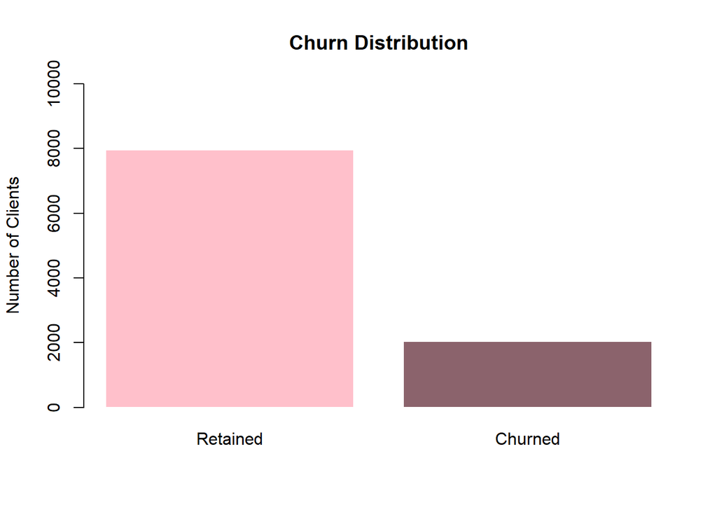

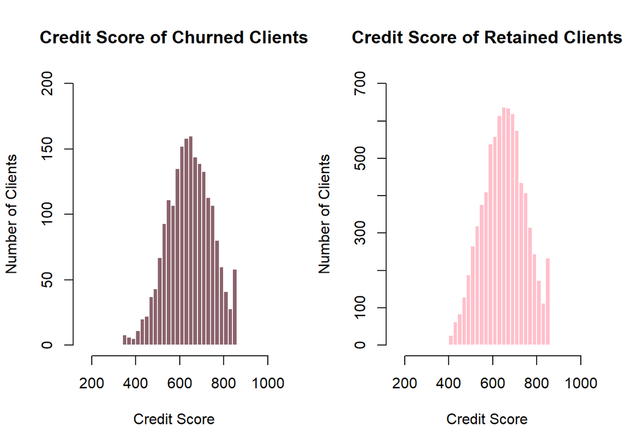

The CreditScore column keeps an information about clients credit score. There is no noticeable difference between the two groups.

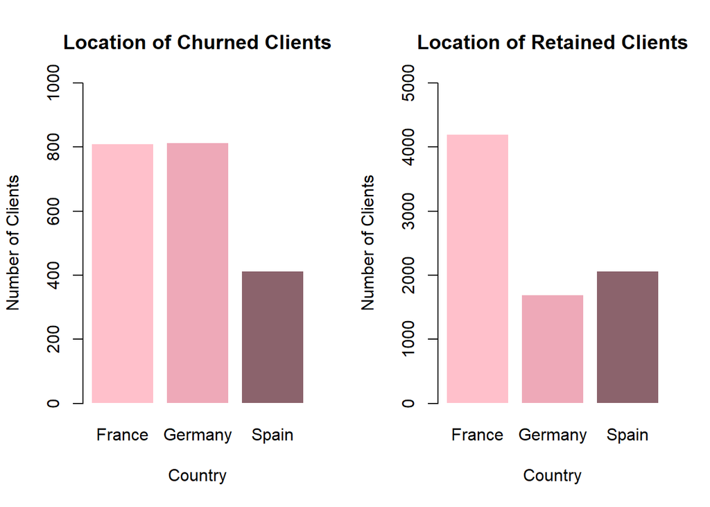

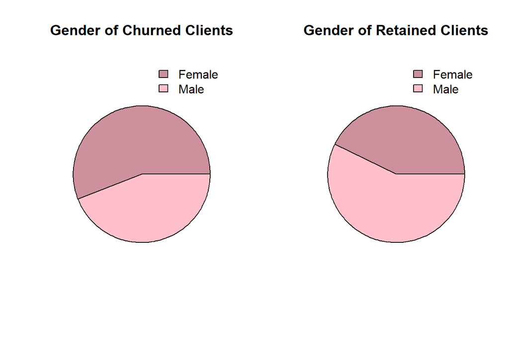

When analyzing two groups separately we observe that gender could be a factor responsible for customers churn. Female are more tend do leave the bank.

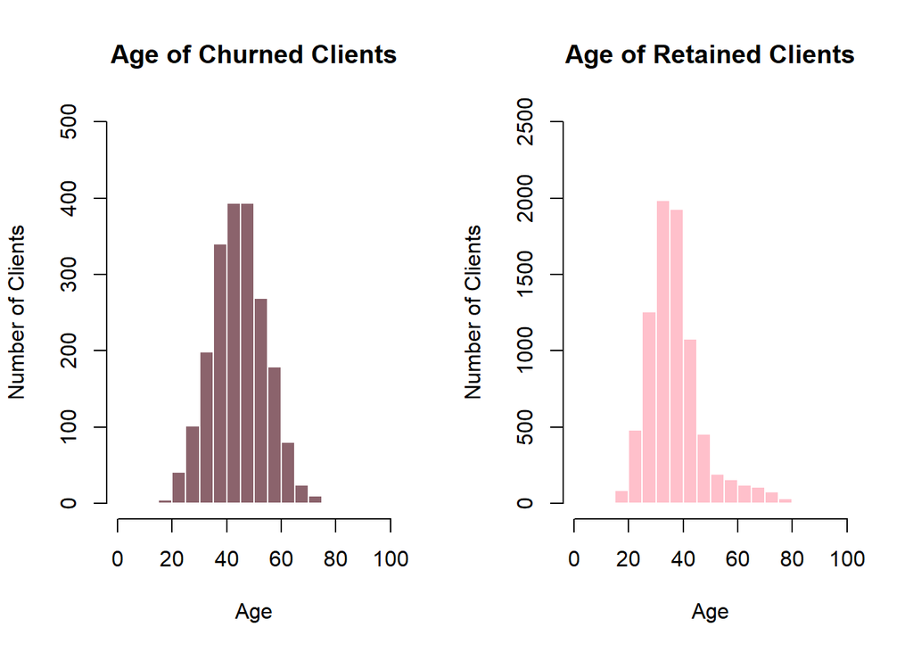

The bank serves customers across a wide age range from 18 to 80 years old. The average age of churned clients is 45, whereas the average age of retained clients is 37. Churned clients tend to be older than retained clients, suggesting that the likelihood of churn increases with age.

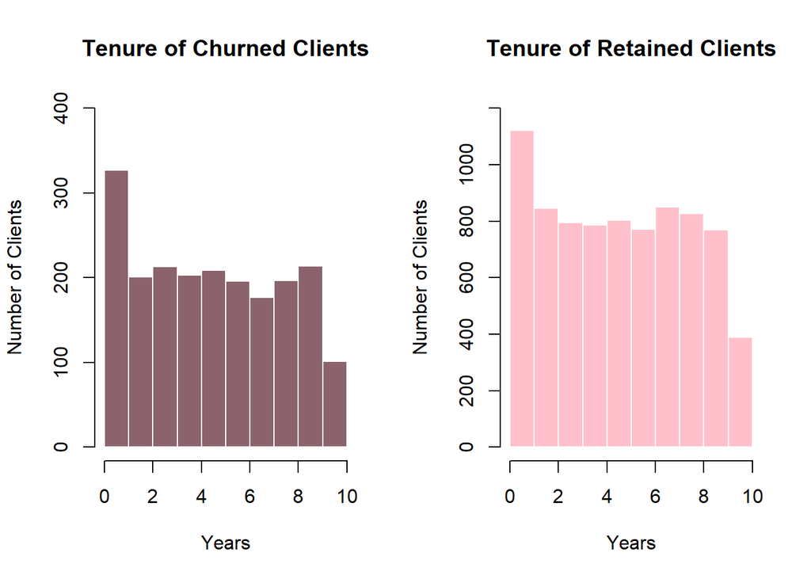

The Tenure column keeps an information on how many years a client has been a member of the bank. This factor has no impact on customer churn.

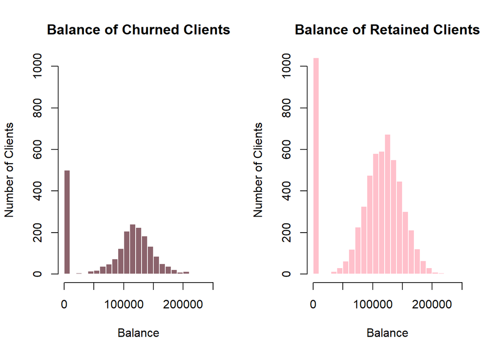

Dataset contains an information on balance of each client. The average balance of churned clients is 91109.48 which is higher than the average balance of retained clients (72742.75).

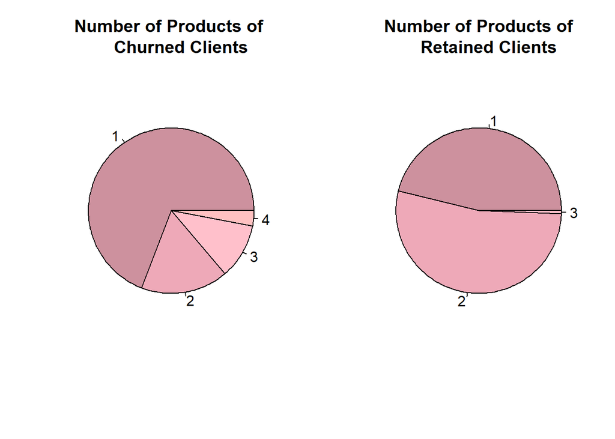

Clients can have multiple products from bank varying from 1 do 4. Most of churned clients had 1 product where as most of the retained clients have at least 2. None of the retained clients have 4 products and very little amount have 3. It could be a factor related to churn behavior.

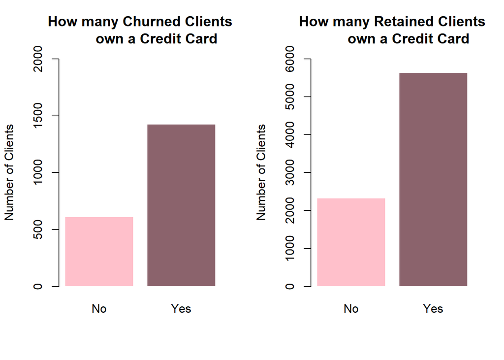

Customers ownership of a credit card has does not influence churn since in both groups distribution is simillar.

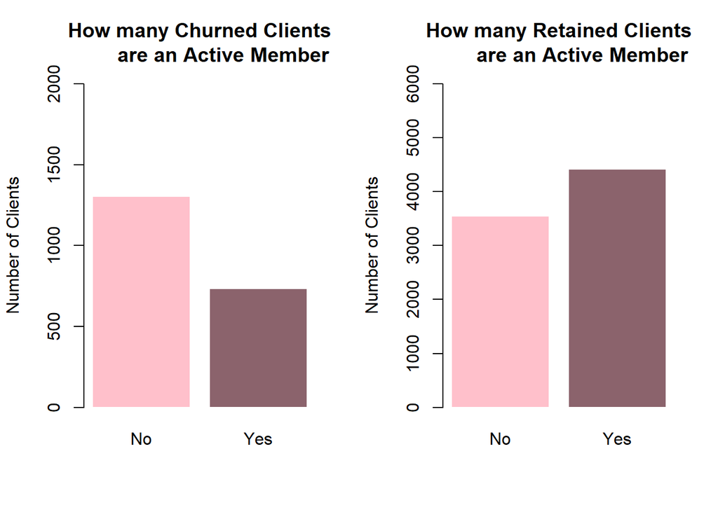

Most of the churned clients were not an active member of the bank. Encouraging customers to become active members may reduce churn.

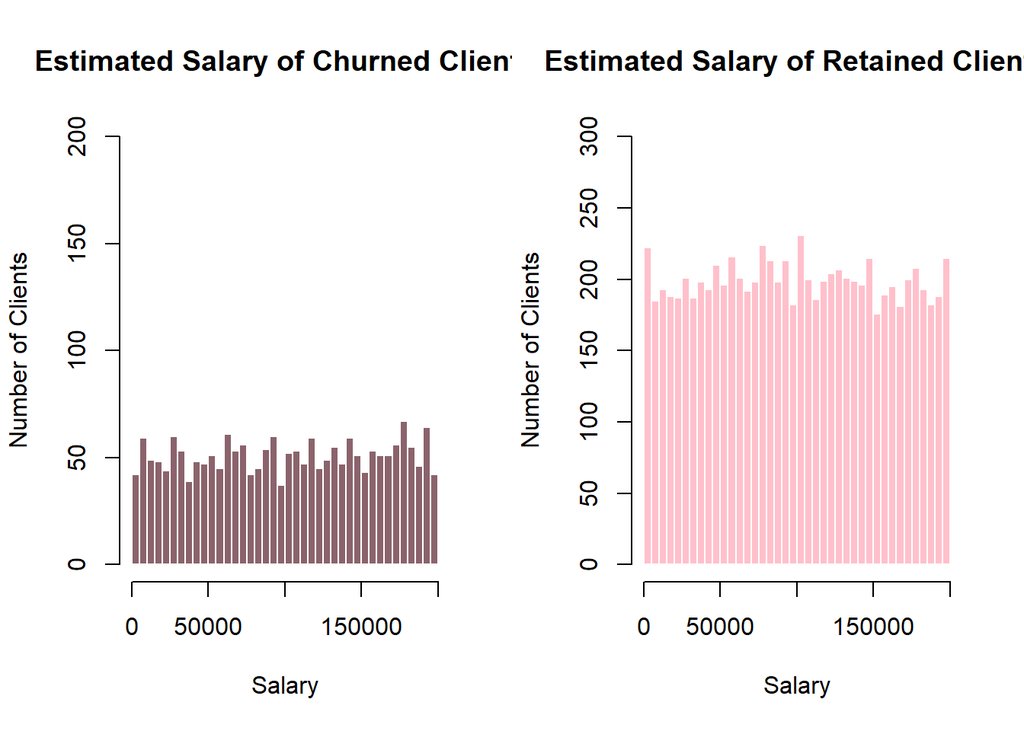

Comparing two plots, estimared salary does not affect churn behavior.

Complaints by Churn Status

|  | No Complaint | Complaint |
| --- | --- | --- |
| Churned | 4 | 2034 |
| Retained | 7952 | 10 |

When analyzing two groups separately we observe that majority of the churned clients has previously filed a complaint. This factor has a strong impact on customer churn, suggesting that unresolved issues or unmet expectations may be driving customers to leave.

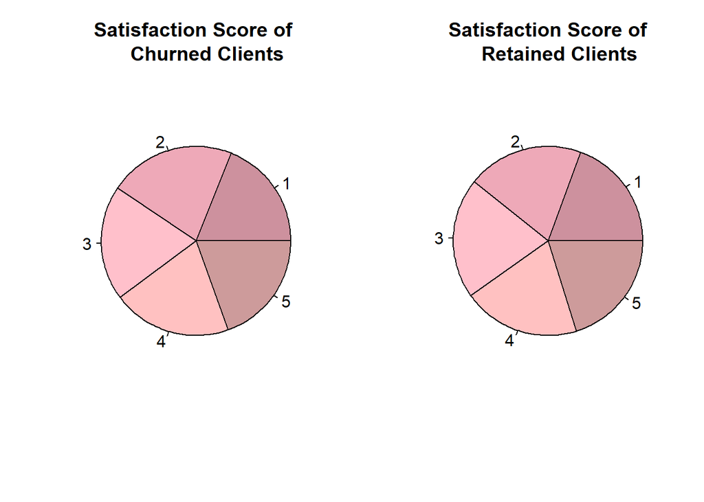

There is no relationship between Satisfaction Score and churn.

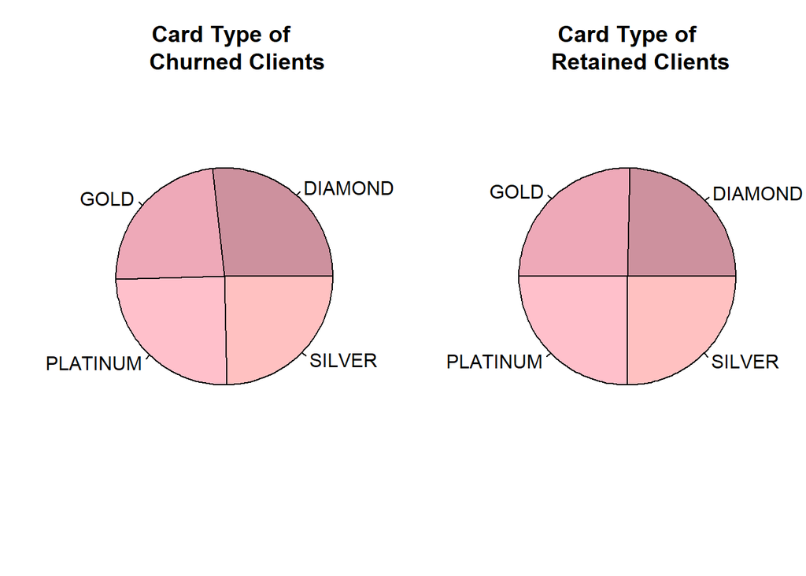

Card type has no effect on customer churn behavior.

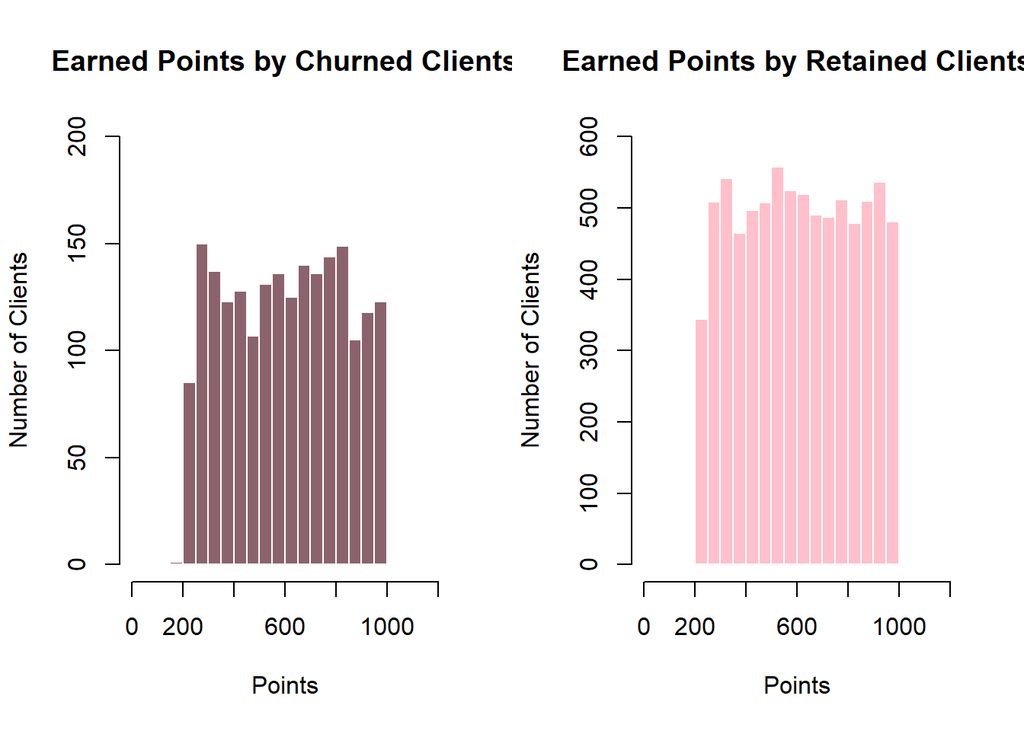

This variable does not influence churn.

# Churn Prediction

In this section, we employ a Random Forest classifier to develop a churn prediction model. This approach allows us to estimate the probability of churn for each customer and identify the most influential factor.

```
##
## Call:
##  randomForest(formula = Exited ~ ., data = learning.set, ntree = 100,      mtry = sqrt(p), importance = TRUE)
##                Type of random forest: classification
##                      Number of trees: 100
## No. of variables tried at each split: 4
##
##         OOB estimate of  error rate: 0.15%
## Confusion matrix:
##      0    1 class.error
## 0 5283    7 0.001323251
## 1    3 1373 0.002180233
```

Random Forest Classification Summary

| Dataset | Accuracy (%) | Error (%) |
| --- | --- | --- |
| Training | 100.00 | 0.00 |
| Test | 99.88 | 0.12 |

The model has been succesfully trained and is now capable of estimating the likelihood of churn for each customer.

For the purposes of this analysis, customers with a churn probability exceeding 20% are classified as high-risk clients.

Churn Probability Distribution

| 0% | 1% | 2% | 3% | 4% | 5% | 6% | 7% | 8% | 9% | 10% | 11% | 14% | 28% | 31% | 32% | 34% | 38% | 40% | 44% | 95% | 98% | 99% |
| --- | --- | --- | --- | --- | --- | --- | --- | --- | --- | --- | --- | --- | --- | --- | --- | --- | --- | --- | --- | --- | --- | --- |
| 6631 | 943 | 213 | 84 | 36 | 12 | 8 | 9 | 4 | 5 | 2 | 3 | 2 | 1 | 1 | 1 | 1 | 1 | 1 | 1 | 1 | 1 | 1 |

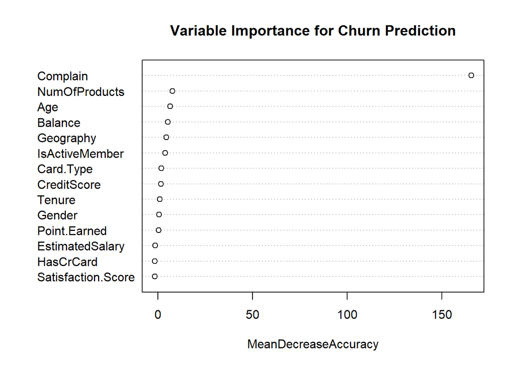

# Conclusion

It is worth focusing on the factors responsible for churn and implementing actions to counteract it. Priority should be given to high-risk clients, followed by maintaining these improvements so that the churn probability of remaining clients stays consistently low.